# Sağlık Sosyolojisi

Sağlık Sosyolojisi Sağlık Bİlİmlerİ Fakültesİ Dr. Tahir Enes Gedik Bahar 2020

[figure not shown]

Dr. Nicolaes Tulp’un Anatomi Dersi (1632), Rembrandt van Rijn

> Bugünlerde iyi bir insan olmak; bedenin günahkâr arzularına gem vurmak, nefsi köreltmek, vicdanın sesine kulak vermek ve sürekli dua edip bu fani dünyayı terk etmeye hazırlanmak anlamına gelmiyor. **Sağlıklı ve mutlu yaşamak anlamına geliyor**. Keyif almadan bir gün geçirenin vay haline!  
> – Hervé Juvin, *The Coming of the Body*, 2010

## Genel Bilgiler

**Dersin kodu ve adı**: Sağlık Sosyolojisi  
**Ders günü/saati ve yeri**: (Henüz belirlenmedi)  
**Dersle ilgili görüşme saati**: (Henüz belirlenmedi)  
**E-posta:** tahirenes.gedik@ikcu.edu.tr

## Dersin İçeriği ve Amacı

Bu dersin amacı öğrencilere sağlık sosyolojisi ile ilgili temel kavram ve tartışmaları tanıtmaktır. Sağlık ve hastalıkla ilgili meseleleri sadece biyolojik boyuta vurgu yaparak ve tıbbi bir yaklaşım benimseyerek anlayamayız. Sağlık ve hastalık ile ilgili anlayışımızı ve fikirlerimizi şekillendiren toplumsal, siyasal, ekonomik ve kültürel güçleri de ele almamız gerekmektedir. Bu amaç doğrultusunda sağlığın/hastalığın kültürel boyutu, sağlık/hastalık deneyimi, tıbbileştirme, sağlıkta eşitsizlik, sağlık meslekleri ve sağlık sistemi gibi konular üzerinde duracağız. Dersin sonunda öğrenciler, sağlık sosyolojisinin temel kavram ve tartışmalarını takip edip bu kavram ve tartışmaları kendi çalışmalarında kullanacak duruma geleceklerdir.

## Dersin İşleniş Biçimi, Kurallar ve Değerlendirme Ölçütleri

#### Yoklama ve Derse Katılım:

Öğrencilerin derse gelmesi **zorunludur** (devam zorunluluğu ile ilgili haklarınızı öğrenmek için lisans yönetmeliğine bakınız). Öğrencilerin derse katılımı ve konuları takip edebilmeleri için okumaları zamanında yapmaları gerekmektedir.

#### Vize ve Final Sınavları:

Vize ve final sınavları çoktan seçmeli ve yazılı bölümlerden oluşmaktadır. Sınav tarihlerinin duyurusu dönem içinde yapılacaktır. Öğrenciler sınavda okumalardan ve derste yapılan tartışmalardan sorumludur. Sınavların kapsamı sınav öncesi öğrencilere duyurulacaktır.

#### Sınıfta Davranış Kuralları:

Sınıfta yapılan tartışmalar sırasında öğrencilerin birbirlerine karşı saygılı olması, gerginliğe sebep olacak davranışlardan kaçınması dersin rahat ve huzurlu işlenmesi için önemlidir.

Derste cep telefonu, dizüstü bilgisayar vb. elektronik cihazların kullanımı yasaktır. Sınıfta bir etkinlik için kullanılmaları gerektiğinde öğrenciler öğretim görevlisi tarafından bilgilendirilecektir.

###### Nasıl E-posta Yazılır?

Dersle ilgili sorularınız ve sorunlarınız için e-posta yoluyla iletişime geçebilirsiniz. E-posta yazarken dikkat etmeniz gereken bazı noktalar bulunmaktadır:

- Anlaşılır ve açıklayıcı bir konu başlığı bulun. E-posta metnini konuya yazmayın.
- Uygun bir hitapla başlayın.
- Konuya doğrudan giriş yapın. Açık bir şekilde sorunuzu yazın ve gereksiz yere e-postayı uzatmayın.
- Uygun bir ifadeyle e-postayı bitirin. Sonuna adınızı ve soyadınızı yazmayı unutmayın.

Bu adımları takip etmemeniz halinde e-postanıza cevap alamazsınız.

| Haftalar | Konular* |  |
| --- | --- | --- |
| 1. Hafta | Ders tanıtımı |  |
| 2. Hafta | Sosyoloji Nedir? Neden Sosyoloji Sağlık Alanıyla İlgilenir? |  |
| 3. Hafta | Tıp ve Tıbbi Yaklaşımlara Tarihsel Bir Bakış Sağlık ve Hastalığın Değişen Anlamı |  |
| 4. Hafta | Demografi ve Epidemiyolojik Geçiş Küresel Sağlık ve Eşitsizlik |  |
| 5. Hafta | Hastalık Deneyimi, Hasta Rolü ve Toplumsal Kontrol |  |
| 6. Hafta | Toplumsal Stres Toplumsal Koşullar ve Sağlıkta Eşitsizlik |  |
| 7. Hafta | Tıbbileş(tir)me |  |
| 8. Hafta | **Vize Haftası** |  |
| 9. Hafta | Tıbbi Otorite ve Bürokrasi: Sağlık Kurumları, Tıbbi Eğitim ve Sağlık Meslekleri Doktor-Hasta İlişkileri |  |
| 10. Hafta | Beslenme ve Sosyoloji |  |
| 11. Hafta | Beden ve Sosyoloji |  |
| 12. Hafta | Osmanlı’dan Cumhuriyet’e Tıp ve Sağlık |  |
| 13. Hafta | Dünyada Sağlık Sistemleri Türkiye’de Sağlık Reformu |  |
| 14. Hafta | Sağlık Sosyolojisi Çalışmalarına Türkiye’den Örnekler |  |
| 15. Hafta | Genel Değerlendirme |  |

***Değişiklikler yapılabilir.**

## Ders Okumaları

Dersle ilgili materyaller öğretim görevlisi tarafından sağlanacaktır. Örnek kaynakça:

##### Türkçe

- Adak, Nurşen. 2015. Sağlık Sosyolojisi: Kadın ve Kentleşme. Siyasal Kitabevi.
- Adak, Nurşen, ed. 2016. *Sağlık Sosyolojisinde Güncel Tartışmalar*. Nobel.
- Cirhinlioğlu, Zafer. 2017. *Sağlık Sosyolojisi*. Nobel.
- Deaton, Angus. 2013. *Büyük Firar: Sağlık, Varlık ve Eşitsizliğin Kökenleri*. Ayrıntı.
- Kasapoğlu, Aytül, ed. 2008. *Madalyonun İki Yüzü: Hastalık Ve Sağlık*. Phoenix.
- Porter, Roy. 2018. *Kan Revan İçinde: Tıbbın Kısa Tarihi*. Metis.
- Tecim, Erhan. 2018. *Sağlık Sosyolojisi*. Çizgi Kitabevi.

##### İngilizce

- Cockerham, William C. 2016. *Medical Sociology*. Routledge.
- Conrad, Peter. 2007. *The Medicalization of Society: On the Transformation of Human Conditions into Treatable Disorders*. The John Hopkins University Press.
- Gabe, Jonathan, Mike Bury, and Mary Ann Elston. 2004. *Key Concepts in Medical Sociology*. Sage.
- Turner, Bryan S. 1995. *Medical Power and Social Knowledge*. Sage.
- Weiss, Gregory L. and Lynne E. Lonnquist. 2015. *The Sociology of Health, Healing, and Illness*. Pearson.
- Weitz, Rose. 2007. *The Sociology of Health, Illness, and Health Care: A Critical Approach*. Thomson Wadsworth.

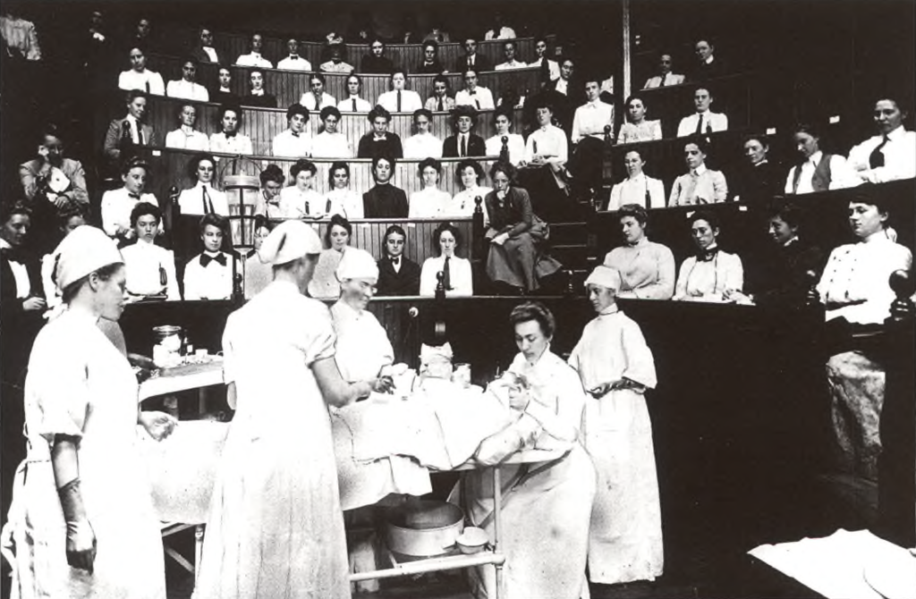

Amerika’da kadınlar tarafından idare edilen ve kadınlara hizmet veren bir hastanede cerrahi operasyon (1907)